# Intelligent healthcare diagnosis

**Introduction**:

Intelligent healthcare diagnosis refers to the emerging field that utilizes artificial intelligence and big data technologies to assist in medical diagnosis and treatment decision-making. It combines medical knowledge with advanced computational methods, aiming to enhance the accuracy, speed, and efficiency of healthcare professionals in diagnosis and provide better patient care and treatment outcomes. Nasopharyngeal carcinoma (NPC) is a common type of head and neck cancer, and early diagnosis is crucial for effective treatment. The study titled "Deep Convolutional Neural Network for Nasopharyngeal Carcinoma Discrimination on MRI by Comparison of Hierarchical and Simple Layered Convolutional Neural Networks" leverages deep learning techniques, specifically convolutional neural networks (CNN), to enhance the accuracy of nasopharyngeal carcinoma diagnosis. Additionally, the study conducts an interpretability analysis of the deep learning models.

**Methods and Problem**:

In MRI image sequences, the high similarity between adjacent images may lead to information leakage when randomly partitioning the dataset based on image context information during training. To address this issue, the research team adopted a patient-level context information approach for dataset partitioning into training and testing sets. To prevent overfitting in the small sample training set, a K-fold cross-validation strategy was employed. During model training, a strategy involving freezing certain layers and introducing pre-trained weights was implemented to enhance the model's learning efficiency and generalization ability. Additionally, to increase the interpretability of the deep learning model, Gradient-weighted Class Activation Mapping (Grad-CAM) was introduced for visualizing feature maps. Through the comparison of the performance of different depths of CNN models, the primary aim of this study is to enhance the learning efficiency of the model and provide robust support for accurate nasopharyngeal carcinoma diagnosis.

After distinguishing the patient's image, the deep neural network is employed to perform image segmentation, thereby further locating the tumor position in the patient. In the field of medical imaging, image segmentation can be used to extract lesions, organs, or tissues from medical images, assisting doctors in disease diagnosis and treatment planning. For example, in magnetic resonance imaging (MRI), image segmentation techniques can be used to segment tumor regions.

**Conclusions**:

By utilizing and comparing CNN models, the study reveals that the ResNet50 model with introduced pre-trained weights performs more accurately in identifying nasopharyngeal carcinoma in MRI images. This research not only demonstrates the potential of deep learning technology in nasopharyngeal carcinoma diagnosis but also offers intuitive explanations for diagnostic results. The outcomes of this study hold promise in providing valuable assistance tools for medical professionals, offering more precise and interpretable for the MRI imaging diagnosis of nasopharyngeal carcinoma. This research introduces new possibilities for early diagnosis of nasopharyngeal carcinoma and is expected to have widespread applications in future clinical practice.

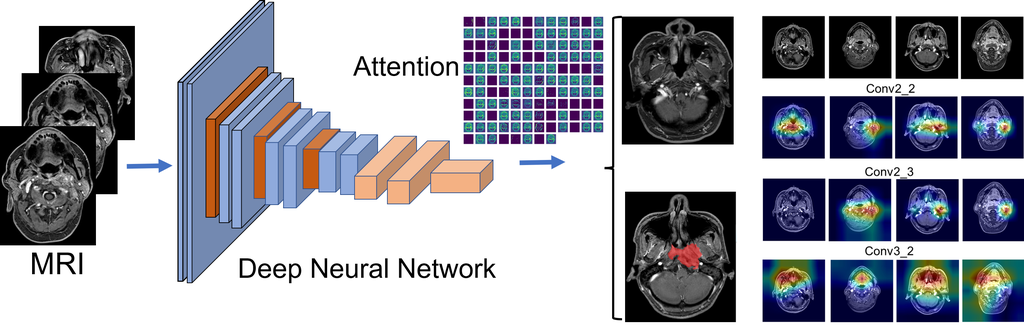

**简介**：

智慧医疗诊断是指利用人工智能和大数据技术来辅助医疗诊断和治疗决策的新兴领域。它结合了医学知识和先进的计算方法，旨在提高医生的诊断准确性、速度和效率，提供更好的患者护理和治疗结果。鼻咽癌（NPC）是一种常见的头颈部癌症，早期诊断对治疗至关重要。使用深度学习技术，特别是卷积神经网络提升了鼻咽癌诊断的准确性。另外，还对深度学习模型进行了可解释性的分析。

**方法和问题**：

在MRI图像序列中，由于相邻图像的高相似性，基于图像上下文信息随机划分的数据集在训练过程中可能导致信息泄漏。为解决这一问题，研究团队采用了通过患者级别的上下文信息来划分为训练集或测试集。对于小样本训练集，为防止过拟合，使用K折交叉验证的策略。在模型训练时，通过冻结部分层并引入预训练权重的策略，旨在提高模型的学习效率和泛化能力。此外，为增加深度学习模型的可解释性，引入了梯度加权类激活图（Grad-CAM）对特征图进行可视化。通过比较不同深度的CNN模型性能，旨在确定最佳的诊断模型。这项研究主要目的是提升模型的学习效率，为鼻咽癌的准确诊断提供更有力的支持。

在区分出患者的图像之后，借助深度神经网络进行图像的分割，从而进一步定位到患者的肿瘤位置。在医学影像领域，图像分割可以用于将病灶、器官或组织从医学图像中提取出来，帮助医生进行疾病诊断和治疗计划制定。例如，在磁共振成像（MRI）中，可以使用图像分割技术来分割出肿瘤区域。

**结论**:

这项研究不仅证明了深度学习技术在鼻咽癌诊断中的潜力，还提供了对诊断结果的直观解释。该研究的成果有望为医生提供宝贵的辅助工具，为鼻咽癌的MRI影像诊断提供更为精准和可解释性的方案。这项研究为鼻咽癌的早期诊断提供了新的可能性，并有望在未来的临床实践中得到广泛应用。

Return to Research.